# Study of the SAT scores for NYC schools

In this short project we study the average SAT scores of schools in New York City (NYC) using data from the 2010s downloaded from the [NYC Open Data](https://opendata.cityofnewyork.us/) website. We aim at finding correlations between SAT test results and a school's geographical or social situation.

## Load the data files

We first import the packages we will use: Pandas for woking with datasets, Numpy to perform calculations efficiently, re for working with regular expressions, Pyplot to represent results graphically, and Basemap and Geopandas to draw maps.

```python
import pandas as pd
import numpy as np
import re
import matplotlib.pyplot as plt
from mpl_toolkits.basemap import Basemap
import geopandas
```

We then import the data files in the dictionary `data`:

```python
# directory where the data files are stored
data_dir = '../Data/NYC_schools'

# list of .csv files to be loaded
list_csv_files = [
    '2010__AP__College_Board__School_Level_Results',
    '2010-2011_Class_Size_-_School-level_detail',
    '2006_-_2012_School_Demographics_and_Accountability_Snapshot',
    '2005-2010_Graduation_Outcomes_-_School_Level',
    '2014_-_2015_DOE_High_School_Directory',
    '2012_SAT_Results'
]

# names we cilll use to represent theses files
col_names_csv = [
    'ap_2010',
    'class_size',
    'demographics',
    'graduation',
    'hs_directory',
    'sat_results'
]

# list of .txt files to be loaded
list_txt_files = [
    'masterfile11_gened_final',
    'masterfile11_d75_final'
]

# dictinary wich will ontain the datasets
data = {}

# import the csv files
for i in range(len(list_csv_files)):
    data[col_names_csv[i]] = pd.read_csv('{}/{}.csv'.format(data_dir, list_csv_files[i]))

# define the dataset survey combining the information in the two txt files,
# with windows-1252 encoding and tab-separated
survey = pd.concat([
    pd.read_csv('{}/{}.txt'.format(data_dir, txt_file), delimiter = '\t', encoding='windows-1252')
    for txt_file in list_txt_files], axis=0, sort=False)

# ensure a consistent capitalization of 'DBN' between the datasets
data['hs_directory']['DBN'] = data['hs_directory']['dbn']

survey['DBN'] = survey['dbn']

# fields to be retained from the survey dataset
survey_fields = [
    'DBN',
    'rr_s',
    'rr_t',
    'rr_p',
    'N_s',
    'N_t',
    'N_p',
    'saf_p_11',
    'com_p_11',
    'eng_p_11',
    'aca_p_11',
    'saf_t_11',
    'com_t_11',
    'eng_t_11',
    'aca_t_11',
    'saf_s_11',
    'com_s_11',
    'eng_s_11',
    'aca_s_11',
    'saf_tot_11',
    'com_tot_11',
    'eng_tot_11',
    'aca_tot_11',
]

data['survey'] = survey.loc[:,survey_fields]
```

The `class_size` dataset has no `DBN` field. Let us add it by combining the information in the `CSD` and `SCHOOL CODE` columns:

```python
def pad_csd(num):
    '''
    pad a number with a 0 if it has only one digit and return its string
    representation; num is a positive integer
    '''
    if num > 9:
        return str(num)
    else:
        return '0' + str(num)

data['class_size']['DBN'] = data['class_size']['CSD'].apply(pad_csd) + data['class_size']['SCHOOL CODE']
```

## Data cleaning

We first convert the columns containing string representation of numbers to numeric values, add a column `sat_score` to `sat_results` containing the total averaged SAT score, and add columns `lat` and `lon` to `hs_directory` contzining, respectively, the latitude and longitude of the school locations.

```python
# columns from the sat_results dataframe whose entries should be converted
cols = ['SAT Math Avg. Score', 'SAT Critical Reading Avg. Score', 'SAT Writing Avg. Score']

# change the values to numeric
# "errors='coerce'" ensures that entries not properly parsed are set to NaN
for col in cols:
    data['sat_results'][col] = pd.to_numeric(data['sat_results'][col], errors='coerce')

# compute the total SAT score and store it in the sat_score column of the sat_results dataframe
data['sat_results']['sat_score'] = data['sat_results'][cols[0]] + data['sat_results'][cols[1]] + data['sat_results'][cols[2]]

# columns from the ap_2010 dataframe whose entries should be converted
cols = ['AP Test Takers ', 'Total Exams Taken', 'Number of Exams with scores 3 4 or 5']

# change the values to numeric
# "errors='coerce'" ensures that entries not properly parsed are set to NaN
for col in cols:
    data['ap_2010'][col] = pd.to_numeric(data['ap_2010'][col], errors='coerce')

# function to find the latitute from strings in the 'Location 1' columns of the 'hs_directory' dataset
def find_lat(location):
    try:
        return float(re.search('\((.+), .+\)', location)[1])
    except TypeError:
        return np.nan

# function to find the longitute from strings in the 'Location 1' columns of the 'hs_directory' dataset
def find_lon(location):
    try:
        return float(re.search('\(.+, (.+)\)', location)[1])
    except TypeError:
        return np.nan

# create the columns lat and lon in the hs_directory dataframe, containing
# respectively the latitude ad longitude of the schools
data['hs_directory']['lat'] = data['hs_directory']['Location 1'].apply(find_lat)
data['hs_directory']['lon'] = data['hs_directory']['Location 1'].apply(find_lon)
```

We then condense the datasets, keeping only the relevent information.

```python
# keep only class size data related to grades 9 to 12 for the 'GEN ED' program
class_size = data['class_size'][
    (data['class_size']['GRADE '] == '09-12')
    & (data['class_size']['PROGRAM TYPE'] == 'GEN ED')
]

# keep only one row by DBN, averaging over entries with the same DBN
class_size = class_size.groupby('DBN').agg(np.mean)
class_size.reset_index(inplace=True)

# update the class_size dataframe in the data disctionary
data['class_size'] = class_size

# keep only demographic data for the year 2011-2012
data['demographics'] = data['demographics'][data['demographics']['schoolyear'] == 20112012]

# keeping only graduation data correponding to the total 2006 cohort
data['graduation'] = data['graduation'][
    (data['graduation']['Cohort'] == '2006')
    & (data['graduation']['Demographic'] == 'Total Cohort')
]
```

Combine the datasets in `combined`:

```python
combined = data['sat_results']

# datasets to be merged with a left join
to_merge_left = ['ap_2010', 'graduation']
for m in to_merge_left:
    combined = combined.merge(data[m], on='DBN', how='left')

# datasets to be merged with an inner join
to_merge_inner = ['class_size', 'demographics', 'survey', 'hs_directory']
for m in to_merge_inner:
    combined = combined.merge(data[m], on='DBN', how='inner')

# fill nan values with the column average if possible, or with 0 otherwie
combined = combined.fillna(combined.mean())
combined = combined.fillna(0)
```

```python
combined['school_dist'] = combined['DBN'].str[0:2]
```

## Finding correlations between the SAT score and survey parameters

We now look for correlations between the average SAT scores and parameters of the survey.

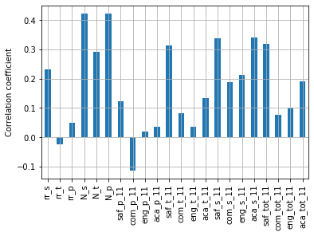

```python
survey_fields.remove('DBN') # the DBN entry is not useful here

# correlation coefficients between the sat_score column and survey fields
correlations = combined[['sat_score'] + survey_fields].corr()['sat_score'][1:]

# make a bar plot of the result
correlations.plot.bar()
plt.ylabel('Correlation coefficient')
plt.grid()
plt.show()
```

There are significant positive correlations (correlation coefficient larger than 0.2) between the SAT scores and

Let us investigate the safety scores more closely. We first plot the sat score versus the safety score based on student response:

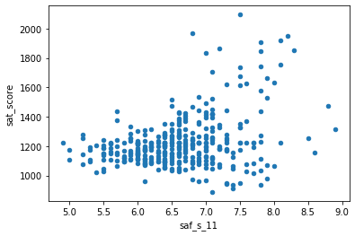

```python
combined.plot.scatter(x = 'saf_s_11', y = 'sat_score')
plt.show()
```

We see a kind of positive correlation, which is consistent with the above finding. Let us now plot the average safety score based on student response for each district using the Basemap module:

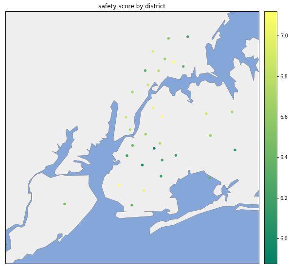

```python
# average of the saf_s_11 score, longitude, and latitude for schools in each district
saf_s_by_district = combined[['school_dist', 'saf_s_11', 'lon', 'lat']].groupby('school_dist').aggregate(np.mean)

# draw the map using Basemap
plt.figure(figsize=(10,10))
m = Basemap(
    projection='merc', # Mercator projection
    llcrnrlat=40.496044,
    urcrnrlat=40.915256,
    llcrnrlon=-74.255735,
    urcrnrlon=-73.700272,
    resolution='h' # high resolution
)

# draw map boundaries, coatlines, rivers, and fill land,
m.drawmapboundary(fill_color='#85A6D9')
m.drawcoastlines(color='#6D5F47', linewidth=.4)
m.drawrivers(color='#6D5F47', linewidth=.4)
m.fillcontinents('#EEEEEE')

# lists of loongitudes and latitudes
longitudes = saf_s_by_district['lon'].tolist()
latitudes = saf_s_by_district['lat'].tolist()

# scatter plot with the color representing the safety score based on
# student response
m.scatter(longitudes, latitudes, s=20, zorder=2, latlon=True,
          c=saf_s_by_district['saf_s_11'], cmap='summer')
m.colorbar()
plt.title('safety score by district')
plt.show()
```

The perceived safety seems generally lower in the north of Brooklyn and higher in Manhattan. Let us confirm this by adding the borough boundaries using Geopandas:

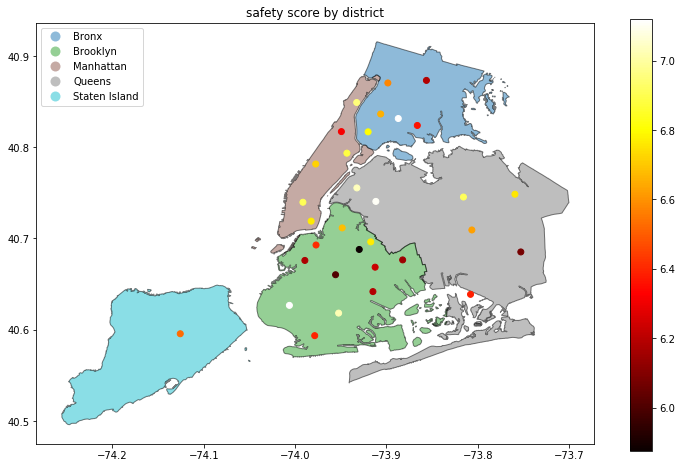

```python
# draw the map of NYC with boroughs filed with different colors
df = geopandas.read_file(geopandas.datasets.get_path('nybb'))
df = df.to_crs(epsg=4326)
ax = df.plot(figsize=(10, 10), alpha=0.5, edgecolor='k', column='BoroName',
             categorical=True, legend=True, legend_kwds={'loc':'upper left'})

# averaged longitude, latitude, and safety score for each district
points = pd.DataFrame({
    'Longitude': saf_s_by_district['lon'].tolist(),
    'Latitude': saf_s_by_district['lat'].tolist(),
    'Score': saf_s_by_district['saf_s_11'].tolist()
})

# scatter plot
plt.scatter(points.Longitude, points.Latitude, c=points.Score, cmap='hot')
plt.title('safety score by district')

#colorbar
fig = ax.get_figure()
cax = fig.add_axes([0.95, 0.2, 0.03, 0.6])
plt.colorbar(cax=cax)
plt.show()
```

The perceived safety seems generally lower in the north of Brooklyn and higher in Manhattan and the north of Queens.

## Evaluating racial inequalities

To estimate if, and to what extent, it is more difficult for pupils from a given background to do well at SAT exams, let us plot the correlations between the `sat_score` column and percentage of pupils of each race.

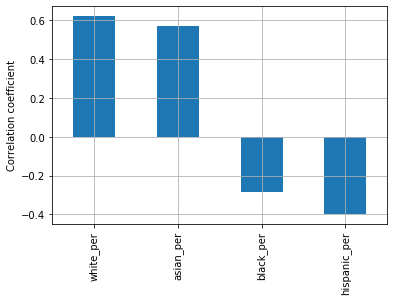

```python
columns_origin = [
    'white_per',
    'asian_per',
    'black_per',
    'hispanic_per'
]
correlations_race = combined[['sat_score'] + columns_origin].corr()['sat_score'][1:]
correlations_race.plot.bar()
plt.ylabel('Correlation coefficient')
plt.grid()
plt.show()
```

There is strong positive correlation between the percentages of white or asian students and SAT scores, small negative correlation with the percentage of black students, and somewhat strong negative correlation with the percentage of hispanic students. Let us investigate the latter using a scatter plot.

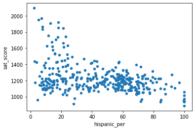

```python
combined.plot.scatter(x = 'hispanic_per', y = 'sat_score')
plt.show()
```

Besides showing the negative trend, this plot seems to indiate that most schools with more than 50% of hispanic students have averaged SAT scores below 1400, and none have an average SAT score above 1500. There also seems to be a group of schools with nearly or exactly 100% hispanic students, doing particularly poorly. Let us try too investigate this. We first show the names of schools with more than 95% hispanic students.

```python
combined[combined['hispanic_per'] > 95]['SCHOOL NAME']
```

```
44                         MANHATTAN BRIDGES HIGH SCHOOL
82      WASHINGTON HEIGHTS EXPEDITIONARY LEARNING SCHOOL
89     GREGORIO LUPERON HIGH SCHOOL FOR SCIENCE AND M...
125                  ACADEMY FOR LANGUAGE AND TECHNOLOGY
141                INTERNATIONAL SCHOOL FOR LIBERAL ARTS
176     PAN AMERICAN INTERNATIONAL HIGH SCHOOL AT MONROE
253                            MULTICULTURAL HIGH SCHOOL
286               PAN AMERICAN INTERNATIONAL HIGH SCHOOL
Name: SCHOOL NAME, dtype: object
```

At least some of them seem to be international schools targetting students from a foreign background, which may explain their difficulties. Let us now look at high schools with a larger than 1800 average SAT score.

```python
combined[combined['sat_score'] > 1800]['SCHOOL NAME']
```

```
5                         BARD HIGH SCHOOL EARLY COLLEGE
37                                STUYVESANT HIGH SCHOOL
79     HIGH SCHOOL FOR MATHEMATICS, SCIENCE AND ENGIN...
151                         BRONX HIGH SCHOOL OF SCIENCE
155    HIGH SCHOOL OF AMERICAN STUDIES AT LEHMAN COLLEGE
187                       BROOKLYN TECHNICAL HIGH SCHOOL
302                          TOWNSEND HARRIS HIGH SCHOOL
327    QUEENS HIGH SCHOOL FOR THE SCIENCES AT YORK CO...
356                  STATEN ISLAND TECHNICAL HIGH SCHOOL
Name: SCHOOL NAME, dtype: object
```

Interestingly, they all have a Wikipedia page, indicating that they are relatively old, well-known institutes, while none of the previous has one. The founding date of the school and its reputation may thus be a factor in its results. (It is, however, not clear to me which is the direction of the causality relation.)

## Evaluating gender inequalities

Let us perform the same analysis with the two columns giving the percentages of male and female students.

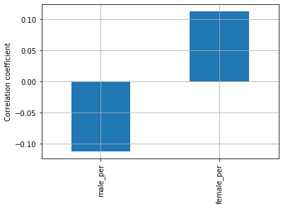

```python
columns_gender = [
    'male_per',
    'female_per',
]
correlations_gen = combined[['sat_score'] + columns_gender].corr()['sat_score'][1:]
correlations_gen.plot.bar()
plt.ylabel('Correlation coefficient')
plt.grid()
plt.show()
```

There is a small (barely above 0.1) negative (respectively positive) correlation between the percentage of male (resp. female) students and averaged SAT score. Again let us show the data on a scatter plot:

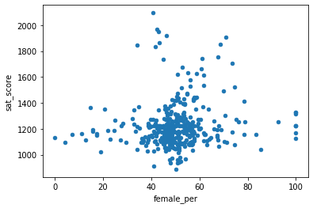

```python
combined.plot.scatter(x = 'female_per', y = 'sat_score')
plt.show()
```

It seems that most schools have between 40% and 60% female students. The best-performing schools have between 30% and 80% female students.

## SAT score versus AP exams

We now want to see if, and to what extent, the percentage of students taking AP exams is correlated with a school's averaged SAT score. To this end, we first add a column `ap_per` to `combined` giving this percentage. We then show a scatter plot of the averaged SAT score versus this new column, and compute their correlation.

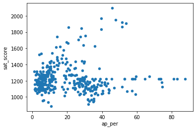

```
Correlation coefficient: 0.057170813907669635
```

```python
combined['ap_per'] = 100. * combined['AP Test Takers '] / combined['total_enrollment']
combined.plot.scatter(x = 'ap_per', y = 'sat_score')
plt.show()
print('Correlation coefficient: {}'.format(combined[['sat_score','ap_per']].corr()['sat_score'][1]))
```

The correlation coefficient is positive, but quite small. From the scatter plot, it seems that some, but not all, schools with a high percentage of AP test takers have higher SAT averages. The data seems to point to two distinct categories of schools: one whose averaged SAT is strongly correlated with the percentage of students taking AP tests and one for whom these numbers are uncorrelated.

The first group of schools is made of those with a high average SAT score. As mentioned above, they tend to be old, well-known schools. The second group contains, notably, all schools with more than 70% of AP test takers. Let us print their names:

```python
combined[combined['ap_per'] > 70]['SCHOOL NAME']
```

```
6      47 THE AMERICAN SIGN LANGUAGE AND ENGLISH SECO...
31                 MANHATTAN ACADEMY FOR ARTS & LANGUAGE
33             INTERNATIONAL HIGH SCHOOL AT UNION SQUARE
83             HIGH SCHOOL FOR EXCELLENCE AND INNOVATION
111                            BRONX BRIDGES HIGH SCHOOL
208                              FRANCES PERKINS ACADEMY
222               THE BROOKLYN ACADEMY OF GLOBAL FINANCE
335                              CAMBRIA HEIGHTS ACADEMY
Name: SCHOOL NAME, dtype: object
```

An internet searc reveals than these shools are mostly attended by minority, socially disadvantaged, or international pupils. Those pupils may feel they need to wor harder than others to succeed, which could explain the high percentage taking AP tests.

Let us aso show the geographic repartitions of these two groups of schools, respectively in red and orange:

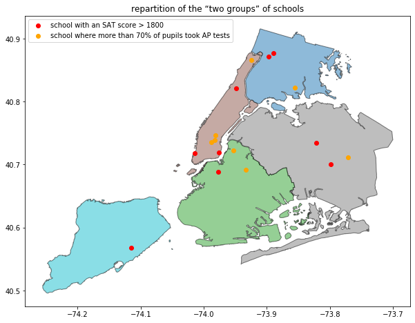

```python
# draw the map of NYC with boroughs filed with different colors
df = geopandas.read_file(geopandas.datasets.get_path('nybb'))
df = df.to_crs(epsg=4326)
ax = df.plot(figsize=(10, 10), alpha=0.5, edgecolor='k', column='BoroName',
             categorical=True, legend=True, legend_kwds={'loc':'upper left'})


points_1 = pd.DataFrame({
    'Longitude': combined[combined['sat_score'] > 1800]['lon'].tolist(),
    'Latitude': combined[combined['sat_score'] > 1800]['lat'].tolist()
})

points_2 = pd.DataFrame({
    'Longitude': combined[combined['ap_per'] > 70]['lon'].tolist(),
    'Latitude': combined[combined['ap_per'] > 70]['lat'].tolist()
})

# scatter plot
plt.scatter(points_1.Longitude, points_1.Latitude, c='r', label='school with an SAT score > 1800')
plt.scatter(points_2.Longitude, points_2.Latitude, c='orange', label='school where more than 70% of pupils took AP tests')
plt.legend(loc='upper left')
plt.title('repartition of the “two groups” of schools')
plt.show()
```

These schools' locations does not seem to provide any particular information.

## SAT score versus total enrollment

Finally, let us see if there is a correlation between the averaged SAT score and total enrollment:

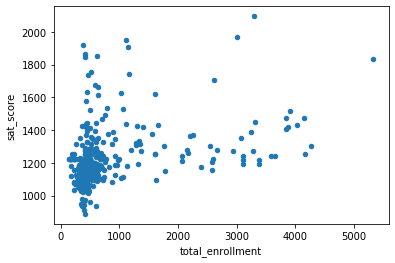

```
Correlation coefficient: 0.36785691698802886
```

```python
combined.plot.scatter(x = 'total_enrollment', y = 'sat_score')
plt.show()
print('Correlation coefficient: {}'.format(combined[['sat_score','total_enrollment']].corr()['sat_score'][1]))
```

There seems to be a significant positive correlation between the two (correlation coefficient larger than 0.36).

### Districts with the highest and lowest SAT scores

Let us now see whih distrcts have the highest and lowest SAT scores, averaged over all schools.

```python
avg_sat_dist = combined[['school_dist', 'sat_score']].groupby('school_dist').aggregate(np.mean).sort_values('sat_score', ascending=False)

print('Highest-SAT score districts:')
display(avg_sat_dist.head(5))

print('Lowest-SAT score districts:')
display(avg_sat_dist.tail(5))
```

```
Highest-SAT score districts:
```

| school_dist | sat_score |
| --- | --- |
| 22 | 1450.5 |
| 31 | 1382.5 |
| 26 | 1377.6 |
| 25 | 1357.0 |
| 01 | 1354.5 |

```
Lowest-SAT score districts:
```

| school_dist | sat_score |
| --- | --- |
| 16 | 1120.109701 |
| 32 | 1119.500000 |
| 18 | 1118.000000 |
| 19 | 1103.833333 |
| 12 | 1101.823134 |

The districts with highest averaged SAT scores are districts 22, 31, 26, 25, and 01. The districts with lowest averaged SAT scores are districts 16, 32, 18, 19, and 12.

### Boroughs with the highest and lowest SAT scores

Let us do the same with the boroughs.

```python
combined[['borough', 'sat_score']].groupby('borough').aggregate(np.mean).sort_values('sat_score', ascending=False)
```

| borough | sat_score |
| --- | --- |
| Staten Island | 1382.500000 |
| Queens | 1286.753032 |
| Manhattan | 1278.331410 |
| Brooklyn | 1181.364461 |
| Bronx | 1157.598203 |

The borough with highest average sat score (1382.5) is Staten Island, while the borough with lowest average SAT score (1157.6) is the Bronx.

## Conclusions

The two main conclusions from this brief study of the SAT scores of NYC secondary schools are

- the positive correlations between the average SAT scores and the perceived safety, respect, and engagement scores,
- the fact that schools with an important fraction of pupils from minorities can have lower SAT scores despite a larger fraction of pupils taking AP tests.

This second point may indicate that programs helping recent immigrants or other minorities are needed to ensure all pupils are given the same opportunities to succeed.